# Final Project 231

PSTAT 231

2024-05-14

# Introduction

Mushrooms! 🍄 Who doesn’t love them? In this project, our goal is to develop a machine learning model that predicts whether a wild mushroom is edible or poisonous. I’ll be using a dataset called ‘mushroom.csv’ from Kaggle, which we’ll explore in more detail later. Throughout this project, I will apply various machine learning techniques to create the most accurate model possible for this classification challenge.

[figure not shown]

## Why Mushrooms?

Everyone understands the risks associated with consuming wild mushrooms. What if there was a predictive model that could determine whether a mushroom is edible? Imagine having access to a tool that enhances safety when foraging. For example, you’re camping and gather herbs for a meal; you spot mushrooms that seem perfect for your stir fry, but you’re uncertain if they’re safe to eat. This is where the predictive model proves invaluable.

## Data Description

In this project, we will be working with the “[Mushroom Classification](https://www.kaggle.com/datasets/vishalpnaik/mushroom-classification-edible-or-poisonous?resource=download)” dataset, a public dataset sourced from Kaggle. This dataset encompasses records for 61,069 mushrooms, providing descriptions for hypothetical samples across 173 species of gilled mushrooms. Each mushroom is classified as either edible, poisonous, or of unknown edibility. With **20 attributes** including cap characteristics, stem features, and habitat. Due to the complex nature of mushrooms, no straightforward rules exist for determining their edibility, making this dataset a valuable resource for our analysis.

*Citation*

*Naik, Vishal P. “Mushroom Classification: Edible or Poisonous?” Kaggle, 8 Mar. 2024, www.kaggle.com/datasets/vishalpnaik/mushroom-classification-edible-or-poisonous?resource=download.*

## Project Road Map

We’ll begin by conducting exploratory data analysis (EDA) to better understand our dataset and its variables. Our objective is to predict whether a mushroom is poisonous or not using a binary response variable named “class.” Following the EDA, we’ll split our data into training and testing sets, create a recipe for pre-processing, and prepare for 10-fold cross-validation.

We plan to explore a variety of predictive models including Logistic Regression, Linear Discriminant Analysis, Decision Tree, Random Forest, and K-Nearest Neighbors. We will train these models on the training data, selecting the one that demonstrates the best performance. The chosen model will then be applied to the test dataset to evaluate its effectiveness in accurately predicting the class of mushrooms.

# Exploring Our Data

Before we do anything to our dataset. We have to first load the dataset and see what our data look like. There can be some variables that might need to converted to factors, or some missing values that might need to be cleaned. In this section, there will be some manipulation and tidying of our data before we analyze some of the key variables using visualizations and other functions.

## Loading Packages

First, let’s load in all of our packages.

```r
# Loading all necessary packages
library(tidyverse)
library(dplyr)
library(tidymodels)
library(kknn)
library(ISLR)
library(discrim)
library(ranger)
library(poissonreg)
library(glmnet)
```

```r
library(finalfit)
library(corrr)
library(corrplot)
library(ggplot2)
library(forcats)
library(vip)
library(readr)
library(yardstick)
```

## Loading in the Dataset

Next, load in our raw data.

```r
# Assigning the data to a variable
mushroom <- read_csv("/Users/fionhuang/Desktop/Pstat 131/Final Project/mushroom.csv")
tidymodels_prefer()

# Calling head() to see the first few rows
head(mushroom)
```

```
## # A tibble: 6 × 21
##   class `cap-diameter` `cap-shape` `cap-surface` `cap-color`
##   <chr>          <dbl> <chr>       <chr>         <chr>
## 1 p               15.3 x           g             o
## 2 p               16.6 x           g             o
## 3 p               14.1 x           g             o
## 4 p               14.2 f           h             e
## 5 p               14.6 x           h             o
## 6 p               15.3 x           g             o
## # ℹ 16 more variables: `does-bruise-or-bleed` <lgl>, `gill-attachment` <chr>,
## #   `gill-spacing` <chr>, `gill-color` <chr>, `stem-height` <dbl>,
## #   `stem-width` <dbl>, `stem-root` <chr>, `stem-surface` <chr>,
## #   `stem-color` <chr>, `veil-type` <chr>, `veil-color` <chr>,
## #   `has-ring` <lgl>, `ring-type` <chr>, `spore-print-color` <chr>,
## #   habitat <chr>, season <chr>
```

## Exploring Raw Data

```r
# Checking for number of missing values in each variable
missing_data <- sapply(mushroom, function(x) sum(is.na(x)))
print(missing_data)
```

```
##                class         cap-diameter            cap-shape
##                    0                    0                    0
##          cap-surface            cap-color does-bruise-or-bleed
##                14120                    0                    0
##      gill-attachment         gill-spacing           gill-color
##                 9884                25063                    0
##          stem-height           stem-width            stem-root
##                    0                    0                51538
##         stem-surface           stem-color            veil-type
##                38124                    0                57892
##           veil-color             has-ring            ring-type
##                53656                    0                 2471
##    spore-print-color              habitat               season
##                54715                    0                    0
```

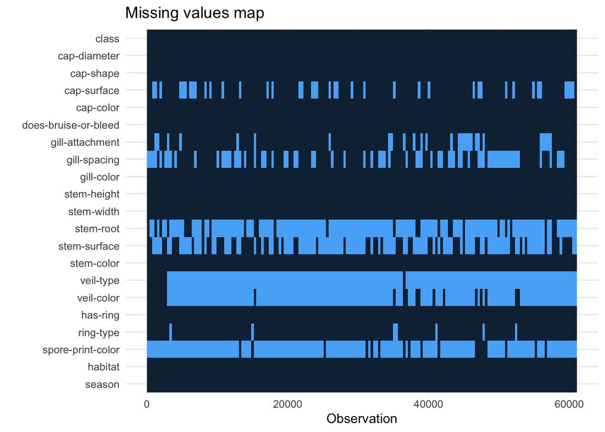

```r
# Plot of missing values in the data
mushroom %>%
  missing_plot()
```

```r
# Number of total missing values
sum(is.na(mushroom))
```

```
## [1] 307463
```

There is a decent amount of missing data we have to deal with. As we can see in our missing values plot, we are missing a lot of data from `cap-surface`, `gill-attachment`, `gill-spacing`, `veil-type`, `stem-root`, `stem-surface`, `veil-color`, `ring-type`, and `spore-print-color`. With so much missing data in all these predictors, we might be forced to remove them from the dataset entirely because it will otherwise impede on our predictions and cause errors.

## Tidying the Data

Now we will tidy up our data. First, we will drop the variables with missing data. Next, we have our response variable `class`, which is currently a binary variable. Our response variable should be a factor, we will reorder the factor so that “p” is the second level. “p” will mean it is poisonous, and “e” will be edible.

```r
drop <- c("cap-surface","gill-attachment", "gill-spacing", "veil-type",
           "stem-root", "stem-surface", "veil-color","ring-type", "spore-print-color")
mushroom <- mushroom[,!(names(mushroom) %in% drop)]

# Make class a factor
mushroom$class <- factor(mushroom$class, labels = c("e", "p"))
mushroom$`cap-shape` <- as.factor(mushroom$`cap-shape`)
mushroom$`cap-color` <- as.factor(mushroom$`cap-color`)
mushroom$`gill-color` <- as.factor(mushroom$`gill-color`)
mushroom$`stem-color` <- as.factor(mushroom$`stem-color`)
mushroom$`has-ring` <- factor(mushroom$`has-ring`, labels = c("FALSE ", "TRUE") )
mushroom$habitat <- as.factor(mushroom$habitat)
mushroom$season <- as.factor(mushroom$season)

# View updated dataset with no miss variables
view(mushroom)
```

## Describing the Predictors

[output not shown]

## Visual EDA

[figure not shown]

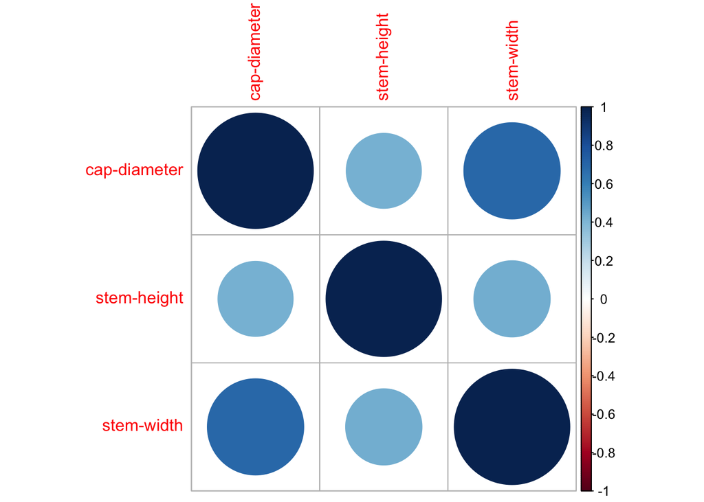

```r
mushroom %>%
  select(where(is.numeric)) %>%
  cor() %>%
  corrplot()
```

### Cap-Diameter

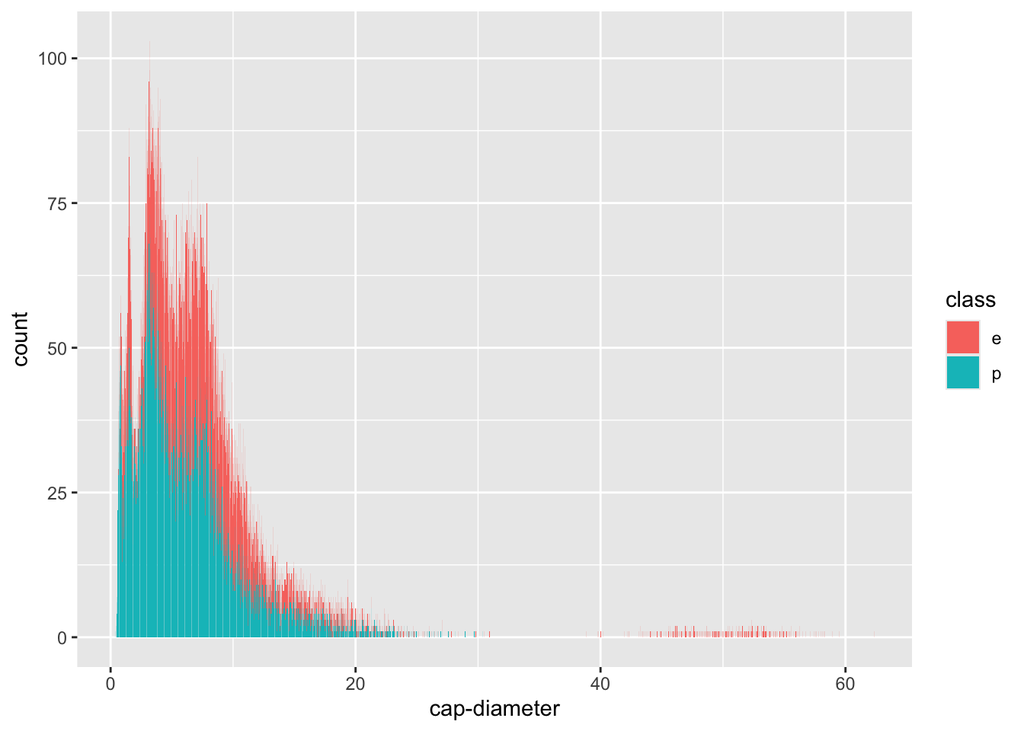

```r
# Barplot of difference in class by cap-diameter
ggplot(mushroom, aes(`cap-diameter`)) +
  geom_bar(aes(fill = class))
```

### Cap-Shape

From this graph mushrooms with ‘x’ (convex), ‘f’ (flat) and ‘s’ (sunken) cap shapes are predominant in both edible and poisonous categories, indicating a common cap morphology across mushroom types. However, there are notable differences in other cap shapes, such as ‘b’ (bell) and ‘o’ (others), which are more dominant among poisonous mushrooms.

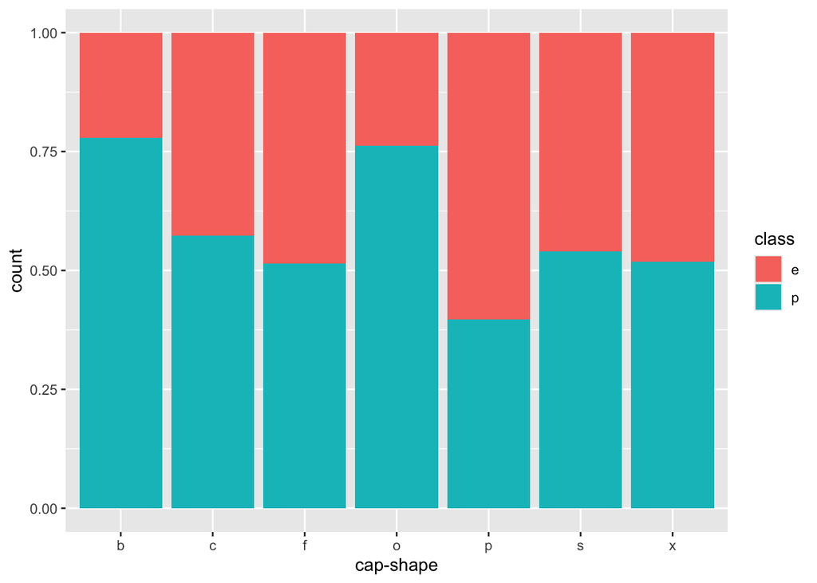

```r
ggplot(mushroom, aes(fill = class,`cap-shape`)) +
  geom_bar(position = "fill")
```

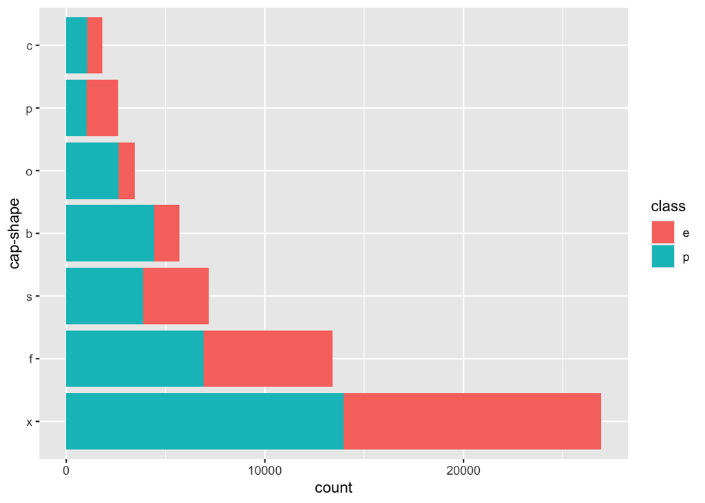

```r
# Barplot of difference in class by cap-shape
mushroom %>%
  mutate(`cap-shape` = fct_infreq(`cap-shape`)) %>%
  ggplot(aes(`cap-shape`)) +
  geom_bar(aes(fill = class)) +
  coord_flip()
```

### Cap-Color

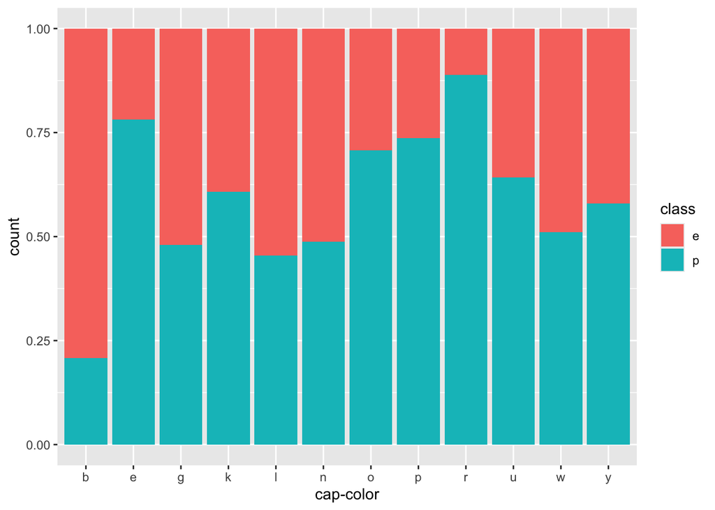

```r
ggplot(mushroom, aes(fill = class,`cap-color`)) +
  geom_bar(position = "fill")
```

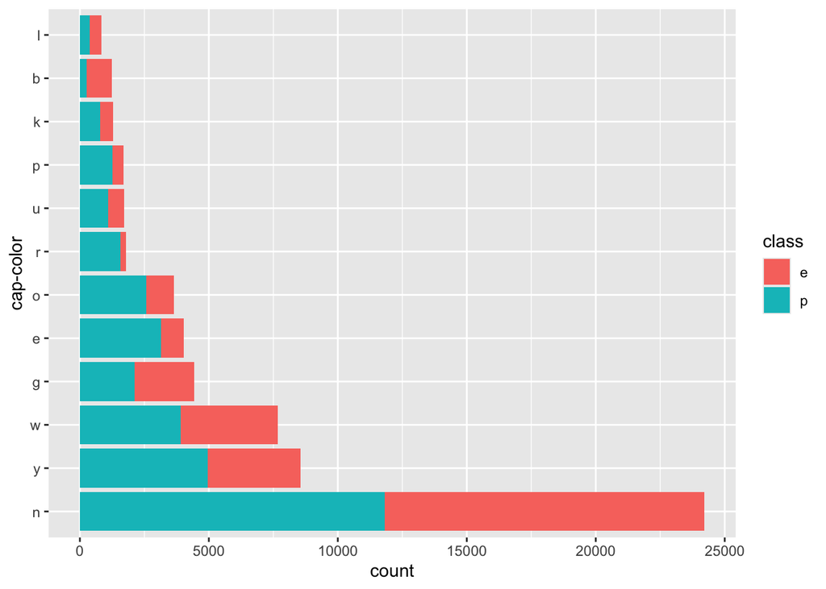

```r
# Barplot of difference in class by cap-color
mushroom %>%
  mutate(`cap-color` = fct_infreq(`cap-color`)) %>%
  ggplot(aes(`cap-color`)) +
  geom_bar(aes(fill = class)) +
  coord_flip()
```

### Bruise or Bleed

Mushrooms that do and do not bruise or bleed have a similar proportion of both edible and poisonous mushrooms. The likelihood of bruising or bleeding might not be a significant factor in determining mushroom toxicity.

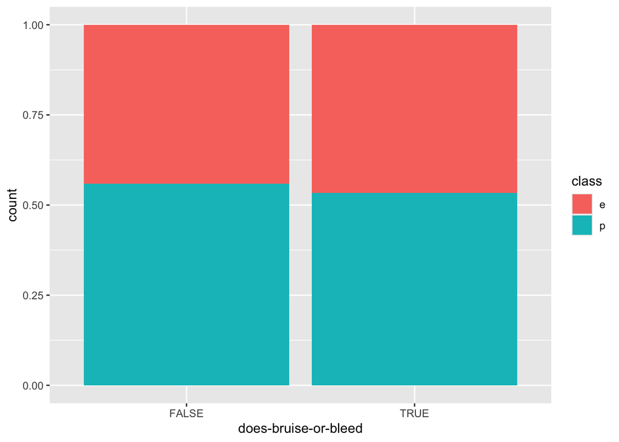

```r
# Barplot of difference in class by bruise-or-bleed
ggplot(mushroom, aes(fill = class, `does-bruise-or-bleed`)) +
  geom_bar(position="fill")
```

### Gill-Color

From this graph we can see that, mushrooms with gill color ‘e’, ‘n’ and ‘f’ are predominantly poisonous, while those with gill color ‘b’ have a higher proportion of edible mushrooms.

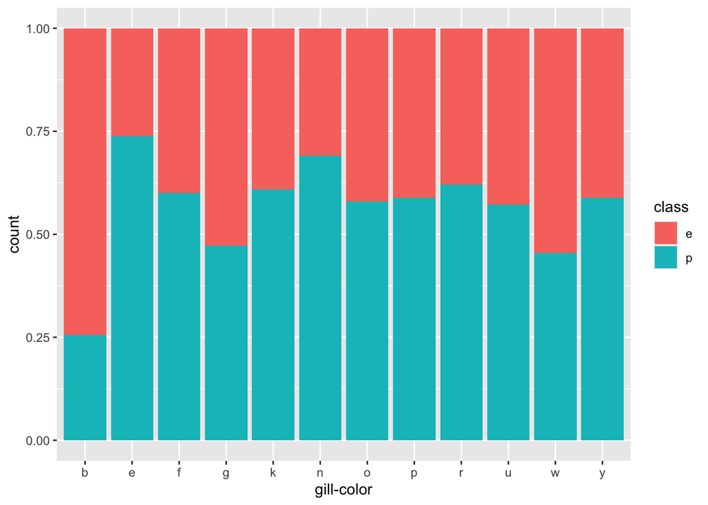

```r
ggplot(mushroom, aes(fill = class, `gill-color`)) +
  geom_bar(position="fill")
```

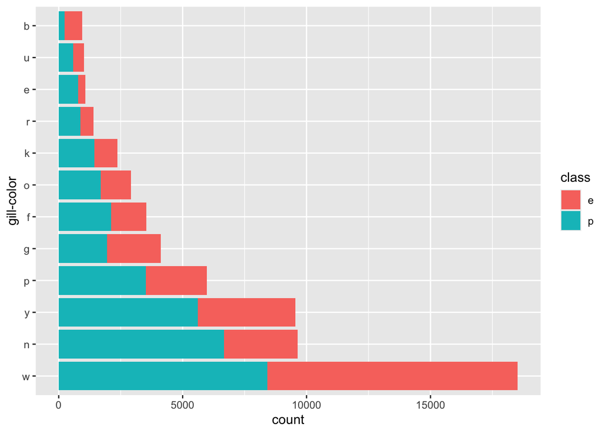

```r
# Barplot of difference in class by gill-color
mushroom %>%
  mutate(`gill-color` = fct_infreq(`gill-color`)) %>%
  ggplot(aes(`gill-color`)) +
  geom_bar(aes(fill = class)) +
  coord_flip()
```

### Stem-Height

Edible mushrooms exhibit a greater stem height on average compared to poisonous mushrooms. The overlapping distributions tells us that stem height alone may not be sufficient for distinguishing between edible and poisonous mushrooms.

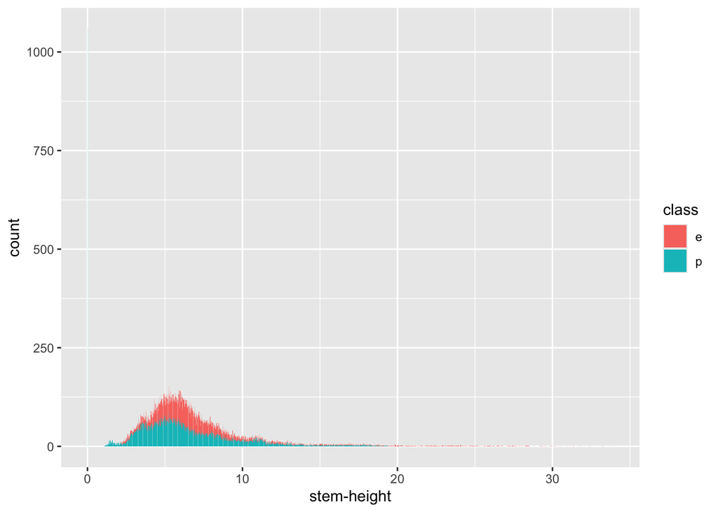

```r
# Barplot of difference in class by stem-height
ggplot(mushroom, aes(`stem-height`)) +
  geom_bar(aes(fill = class))
```

### Stem-Color

Stem color ‘f’ (unknown) has zero proportion of edible mushrooms, indicating it is directly associated with toxicity. Stem color ‘b’ (buff) has zero proportion of poisonous mushrooms, indicating it is not associated with toxicity. Stem color ‘e’ (red), ‘k’ (black), ‘p’ (purple), ‘r’ (green), ‘u’ (purple), ‘y’ (yellow) has a significantly higher proportion of poisonous mushrooms compared to edible ones. Stem color ‘i’ (blue), ‘o’ (orange) and ‘n’ (brown) has a moderately higher proportion of poisonous mushrooms compared to edible ones.

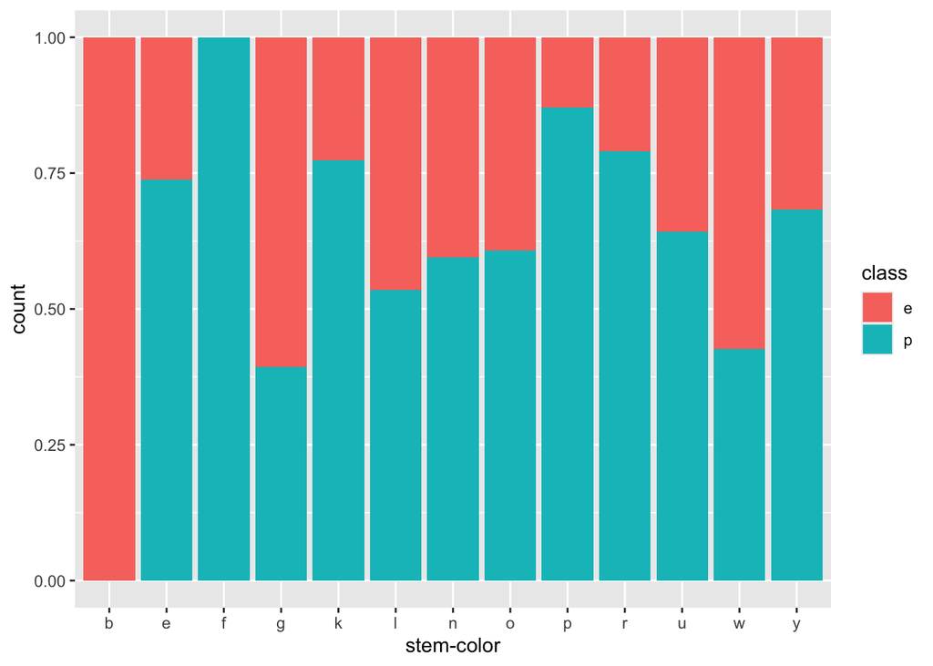

```r
ggplot(mushroom, aes(fill = class, `stem-color`)) +
  geom_bar(position="fill")
```

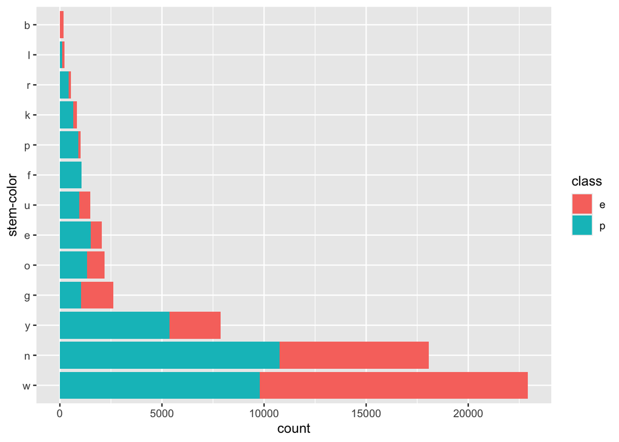

```r
# Barplot of difference in class by stem-color
mushroom %>%
  mutate(`stem-color` = fct_infreq(`stem-color`)) %>%
  ggplot(aes(`stem-color`)) +
  geom_bar(aes(fill = class)) +
  coord_flip()
```

### Has-Rings

Mushrooms with a ring (t) are slightly more poisonous compared to edible ones. This difference in counts suggests that the presence or absence of a ring could be a significant factor in determining whether a mushroom is poisonous or edible.

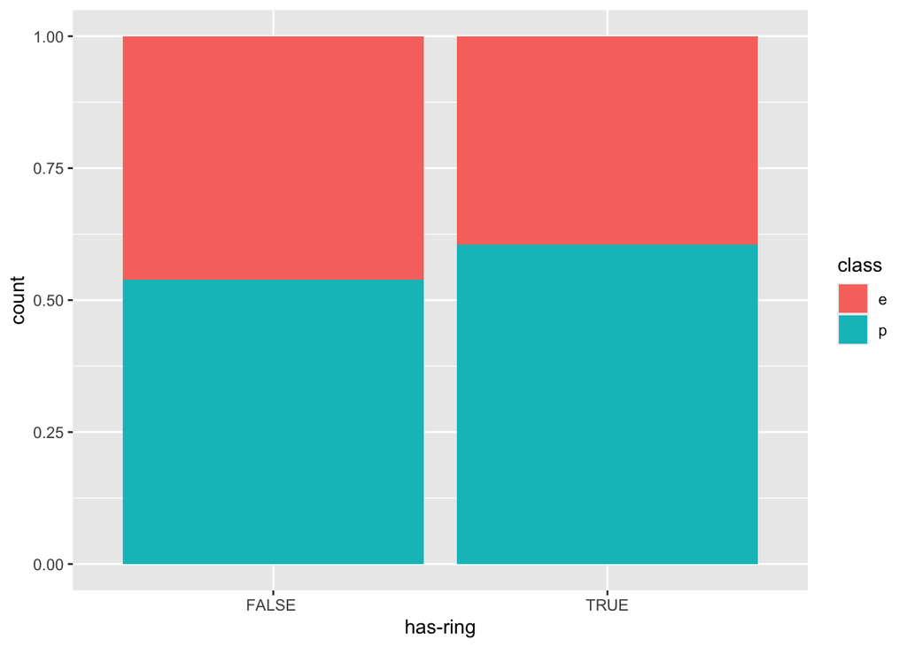

```r
# Barplot of difference in class by has-ring
ggplot(mushroom, aes(fill = class, `has-ring`)) +
  geom_bar(position="fill")
```

### Habitat

Mushrooms found in habitat ‘p’ (paths) is exclusively poisonous and mushrooms found in ‘u’, ‘w’ is exclusively edible. Mushrooms found in habitats ‘d’, ‘g’, and ‘h’ have a moderate proportion of poisonous mushrooms compared to edible ones.

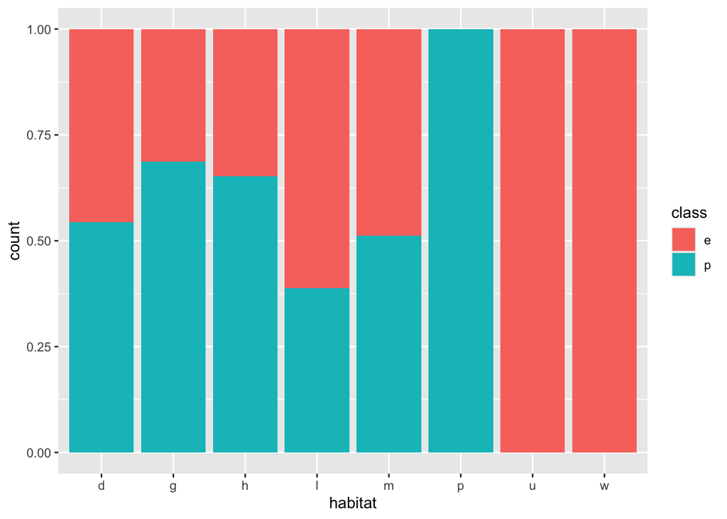

```r
ggplot(mushroom, aes(fill = class, `habitat`)) +
  geom_bar(position="fill")
```

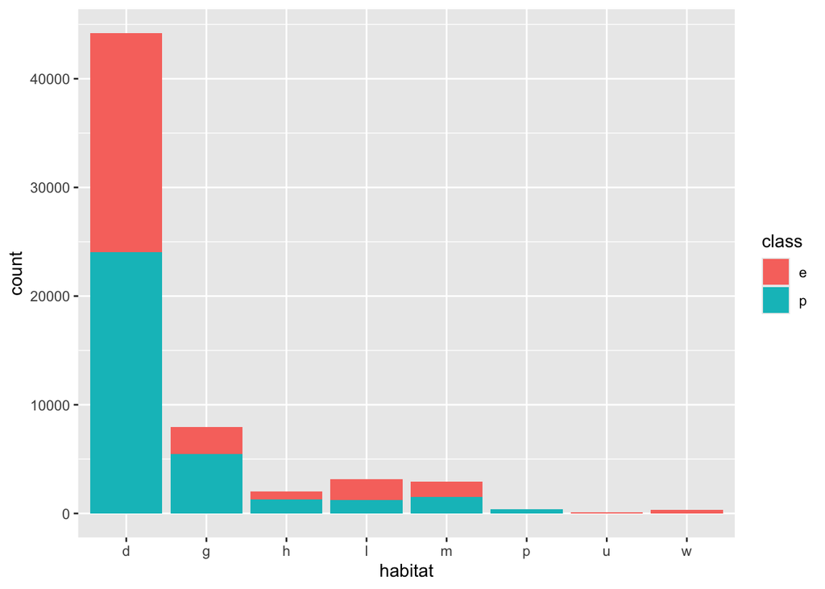

```r
# Barplot of difference in class by habitat
ggplot(mushroom, aes(`habitat`)) +
  geom_bar(aes(fill = class))
```

## Setting up for the Model

Now that we have a better idea of our data, we can finally move on to building our models. We will randomly split our data into training and testing sets, set up and create our recipe, and establish cross-validation within our models.

### Train/Test Split

First to set up our model, we will need to split our data into separate datasets. One will be used for the training of our models, and the other will be the testing set, which is saved till the end and used only once when we actually test our models. Our very first step, is to set our seed so that our random split can be reproduced every time we train our models. Next, we will perform a training / testing split on our data, and stratify on our response variable, `class`.

I will be using a proportion of 0.70, since there is a good amount of observation. The training data has 42,747 observation, while the testing data has 18,322 observation.

```r
set.seed(2002) # Setting a seed so the split is the same

split <- initial_split(mushroom, prop = 0.70,
                                strata = class)
train <- training(split) # Training split
test <- testing(split) # Testing split
split
```

```
## <Training/Testing/Total>
## <42747/18322/61069>
```

```r
# Check the correct number of observations in each data set
dim(test)
```

```
## [1] 18322    12
```

```r
dim(train)
```

```
## [1] 42747    12
```

### Building the Recipe

```r
mushroom_recipe <-   # building the recipe to be used for each model
  recipe(class ~  `cap-diameter` + `cap-shape` + `cap-color` + `gill-color` +
           `stem-height` + `stem-width` + `stem-color` + `has-ring` + `habitat` + `season`,
         data = train) %>%
  step_dummy(`cap-shape`) %>%  # dummy predictor on categorical variables
  step_dummy(`cap-color`) %>%
  step_dummy(`gill-color`) %>%
  step_dummy(`stem-color`) %>%
  step_dummy(`has-ring`) %>%
  step_dummy(habitat) %>%
  step_dummy(season) %>%
  step_center(all_predictors()) %>% # standardizing our predictors
  step_scale(all_predictors())
```

### K-Fold Cross Validation

We are going to use stratified cross validation on our response variable, `class`, to help with the issue of imbalanced data. We will use 10 folds to perform stratifies cross validation.

```r
folds <- vfold_cv(train, v = 10, strata = class)  # 10-fold CV
```

# Building and Fitting the Models

We are now ready to start building and fitting our models. We will fit five different models. These models are Logistic Regression, Linear Discriminant, KNN, Decision Tree, and Random Forest models. The first two models are relatively simple and will take much less time to run. The final three models are the ones we are more interested in, particularly the Random Forest model, as they are better fit for binary classification problems, which is exactly our case.

## Model Building Process

The general workflow of the model building process constituted of the following steps:

1. **Model Setup**: Specify the type of model, set its engine, and define its mode as ‘classification’ due to our project goal.
2. **Workflow Setup**: Create the model’s workflow, add the new model, and incorporate the established recipe.

(For Logistic Regression and Linear Discriminant Analysis we skip steps 3-5 as they do not require hyperparameter tuning.)

3. **Tuning Grid Setup**: Define the parameters to be tuned and set the ranges for different levels of tuning for each parameter.
4. **Model Tuning**: Tune the model using the specified hyperparameters.
5. **Model Selection**: Choose the most accurate model from the tuning grid and finalize the workflow with those tuning parameters.
6. **Model Fitting**: Fit the model with the finalized workflow to our sunset training dataset.
7. **Result Saving**: Save the results to an RDA file for easy loading back into the main project file.

### Fitting the Model

```r
save(folds, mushroom_recipe, train, test, file = "/Users/fionhuang/Desktop/Pstat 131/Final Project/RDA/Model_Setup.rda")

# Logistic Regression
load(file = "/Users/fionhuang/Desktop/Pstat 131/Final Project/RDA/Logistic Regression.rda")

# Linear Discriminant
load(file = "/Users/fionhuang/Desktop/Pstat 131/Final Project/RDA/Linear Discriminate.rda")

# KNN
load(file = "/Users/fionhuang/Desktop/Pstat 131/Final Project/RDA/knn.rda")

# Decision Trees
load(file = "/Users/fionhuang/Desktop/Pstat 131/Final Project/RDA/Decision Tree.rda")

# Random Forest Models
load(file = "/Users/fionhuang/Desktop/Pstat 131/Final Project/RDA/Random Forest.rda")
```

# Model Results

Since our model is on the larger side, I have saved each of their individual outcome and scores into an RDA file and have already load in our results of each model. We can now start analyzing their performances.

## Visualizing Results

### KNN

The bigger the nearest neighbors is the more accurate our model is. The highest ROC AUC a little above 0.998, which is pretty high up there.

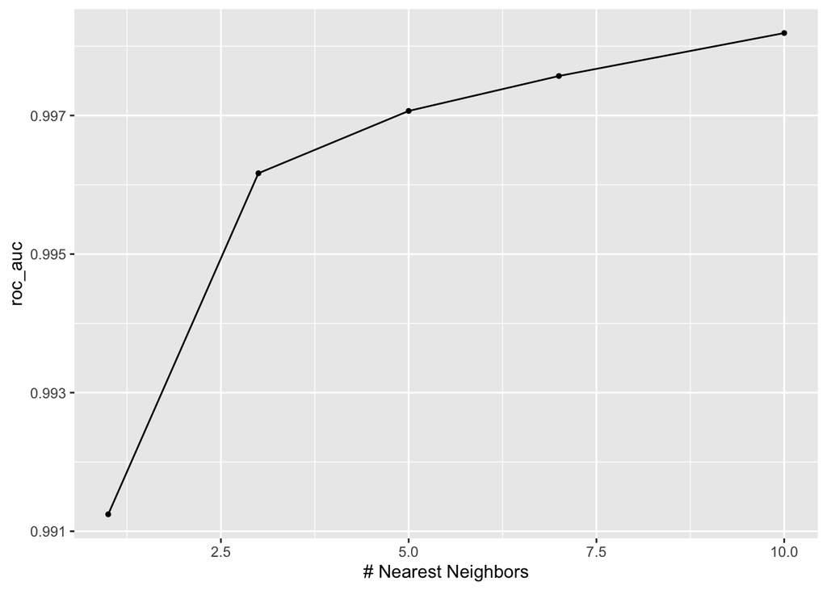

```r
autoplot(knn_tune, metric = "roc_auc")
```

### Random Forest

Let’s now review the autoplot of the second best performing model, random forest.

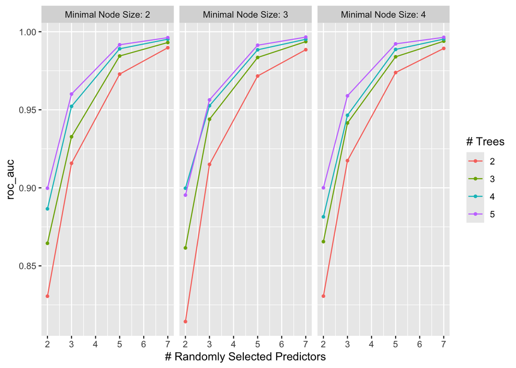

```r
autoplot(rf_tune_auc)
```

### Decision Tree

Now we will review the Decision Tree.

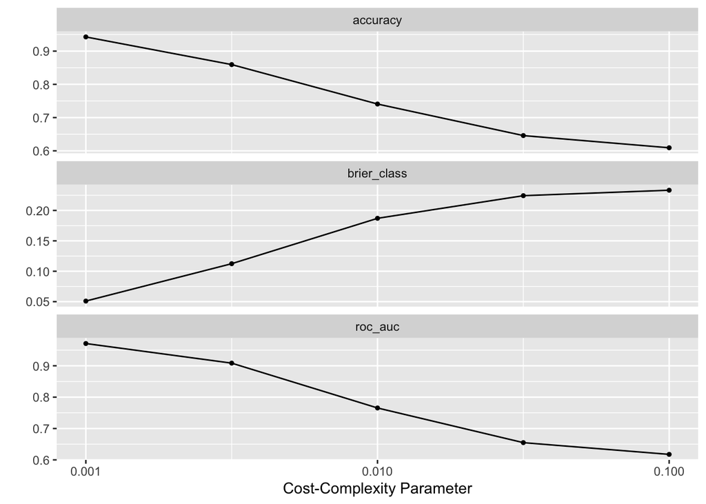

```r
autoplot(tree_tune)
```

### Logistic Regression

Plotting a confusion matrix for logistic regression.

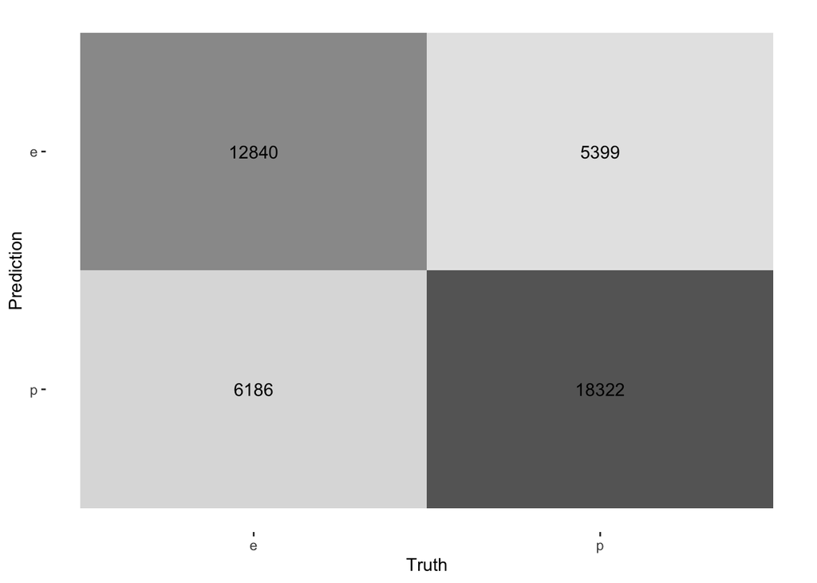

```r
augment(log_fit, new_data = train) %>%
  conf_mat(class, .pred_class) %>%
  autoplot(type = "heatmap")
```

When we plot the confusion matrix for the logistic regression model we can see how many observations the model predicted correctly and the amount of observation the model predicted incorrectly.

## Model Accuracies

Before, we start visualizing our results. We are going to summarize the best ROC AUC values from our five models. That way we can choose our 4 best model to visualize. We will create a tibble in order to display the estimated final `roc_auc` value for each fitted model.

```r
log_auc <- augment(log_fit, new_data = train) %>%
  roc_auc(class, .pred_e) %>%
  select(.estimate)

lda_auc <- augment(lda_fit, new_data = train) %>%
  roc_auc(class, .pred_e) %>%
  select(.estimate)

knn_auc <- augment(knn_final_fit, new_data = train) %>%
  roc_auc(class, .pred_e) %>%
  select(.estimate)

dt_auc <- augment(dt_final_fit, new_data = train) %>%
  roc_auc(class, .pred_e) %>%
  select(.estimate)

rf_auc <- augment(rf_final_fit_auc, new_data = train) %>%
  roc_auc(class, .pred_e) %>%
  select(.estimate)

roc_aucs <- c(log_auc$.estimate,
              lda_auc$.estimate,
              knn_auc$.estimate,
              dt_auc$.estimate,
              rf_auc$.estimate)

model_names <- c("Logistic Regression",
                 "LDA",
                 "KNN",
                 "Decision Tree",
                 "Random Forest")

results <- tibble(Model = model_names,
                  ROC_AUC = roc_aucs)

results <- results %>%
  arrange(-roc_aucs)

results
```

```
## # A tibble: 5 × 2
##   Model               ROC_AUC
##   <chr>                 <dbl>
## 1 KNN                   1.00
## 2 Random Forest         0.999
## 3 Decision Tree         0.975
## 4 Logistic Regression   0.789
## 5 LDA                   0.788
```

# Results From Our Best Models

Now from looking at the ROC of each model we can confidently say that KNN is our best model. With an `roc_auc` of 0.998. Let’s continue with our analysis and fit our model into the testing dataset.

[figure not shown]

## KNN

The k-Nearest Neighbors (k-NN) classification model is a straightforward and intuitive machine learning algorithm used for classifying data points based on the categories of their nearest neighbors. It operates by storing all the training data and does not involve a traditional training phase. When a new data point needs to be classified, the algorithm calculates the distance between this point and all points in the training dataset using a distance metric such as Euclidean distance. It then identifies the k nearest neighbors to the query point, where k is a user-defined constant. The new data point is classified based on a majority vote among the k nearest neighbors, meaning it is assigned the class that is most common among these neighbors. k-NN can be computationally intensive and sensitive to irrelevant features and high-dimensional data. Despite its limitations, k-NN remains a powerful tool for both classification and regression tasks, particularly when interpretability and simplicity are crucial.

### Best Model is…

drum roll please

```r
show_best(knn_tune, metric = "roc_auc") %>% #showing the best rf model
  select(-.estimator, .config) %>%
  slice(1)
```

```
## # A tibble: 1 × 6
##   neighbors .metric  mean     n  std_err .config
##       <int> <chr>   <dbl> <int>    <dbl> <chr>
## 1        10 roc_auc 0.998    10 0.000281 Preprocessor1_Model5
```

### Final ROC AUC Results

Now, the moment we have all been waiting for. We will be fitting our best model into our testing dataset. Let’s take a look!

```r
knn_roc_auc <- augment(knn_final_fit, new_data = test, type = 'prob') %>%
  roc_auc(class, .pred_e) %>%
  select(.estimate)
knn_roc_auc
```

```
## # A tibble: 1 × 1
##   .estimate
##       <dbl>
## 1     0.998
```

With a final ROC AUC score of 0.998 on our testing data, we can say our model is nearly perfect! Next we will visualize our result.

### ROC Curve

Now to visualize our AUC score we will take look at the ROC curve real quick. The higher up and left the curve is, the better the model’s AUC will be. One way to think about it is the more our curve looks like a right triangle the better. As we can see below our curve is nearly perfect meaning our model is a good fit.

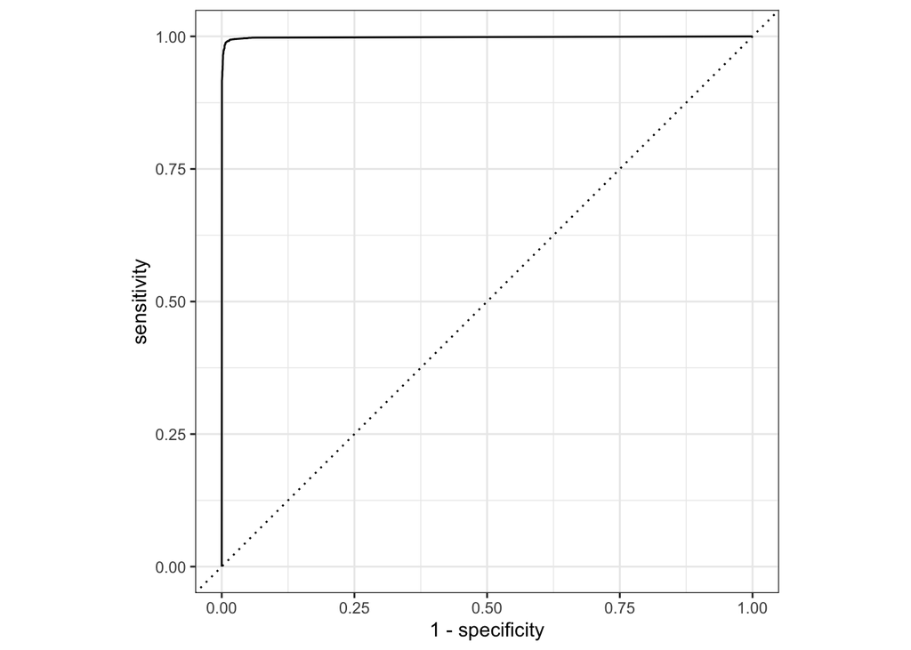

```r
augment(knn_final_fit, new_data = test, type = 'prob') %>%
  roc_curve(class, .pred_e) %>%
  autoplot()
```

### Confusion Matrix

Plotting a confusion matrix for our best performing model shows what how many observations was misclassified and how many observation that was predicated correctly.

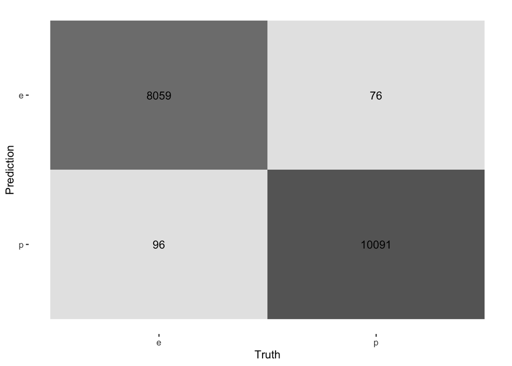

```r
augment(knn_final_fit, new_data = test) %>%
  conf_mat(class, .pred_class) %>%
  autoplot(type = "heatmap")
```

# Conclusion

After fitting five models on ten cross-validated folds and conducting analysis on each, the best model for predicting mushroom edibility appears to be the K-nearest neighbors (KNN) model. KNN is a supervised learning algorithm used for classification and regression tasks. When given a new data point, KNN calculates the distance between this point and all others in the training set. It then selects the k nearest neighbors based on these distances. For classification, the majority class among the k neighbors is assigned to the new data point, whereas for regression, the average target value of the k neighbors is used. KNN is non-parametric and lazy, meaning it makes no assumptions about data distribution and delays computation until prediction time. The choice of hyperparameter k is crucial as it affects the model’s flexibility and performance.

Areas for improvement include handling missing data instead of discarding entire variables, which would provide more data for model training. Despite removing some variables, the models still performed well. Future exploration could involve studying the species of mushrooms and their impact on edibility. Working with this dataset was enjoyable, especially given my interest in various types of mushrooms.

Overall, developing a predictive model to determine mushroom edibility was a valuable experience. It offered the opportunity to work with a large dataset, build machine learning models, and enhance data analysis skills. Building such models is challenging, requiring significant research and determination, but it was ultimately a rewarding experience. I look forward to my next project!